# Advanced Modeling Options

## Good To Know

- Advanced models
  - General high-threshold model
  - Unequal-variance signal detection model
- Model comparison with "unrelated" models
  - AIC
  - BIC
- Problems & Fixes: Null counts

## Advanced Models

## General High-Threshold Model (GHT)

Extension of the double-high-threshold model

[figure not shown]

## General High-Threshold Model

[figure not shown]

## General High-Threshold Model

Let's go back to the change-detection example. How would we fit a general high-threshold version of the fixed-capacity model?

- We do!

## General High-Threshold Model

Let's go back to the change-detection example. How would we fit a general high-threshold version of the fixed-capacity model? We do!

```r
## Varying Capacity Model
ll.vary_k <- function(par, y){
  # length(par) == 5 (k*3, a, g)
  ll=0
  for(i in 1:length(N)){ # for each set size
    p = cowan_k(k = par[i], a = par[4], g = par[5], N = N[i])
    ll = ll + negLL(y[N_i==i], p)  }
  if(any(c(par < rep(0,5), par > c(rep(max(N), 3),1,1)))){
    ll = ll + 10000} # penalty for going out of range
  return(ll)
}

parameter.estimates
```

```
##        k2        k5        k8         a         g
## 2.8622687 7.2591656 4.1207409 0.7379111 0.6412371
```

## Unequal Variance Signal Detection Model (UVSD)

Equal variance:

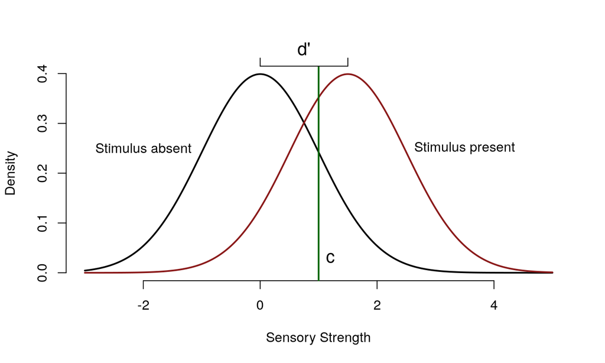

## Unequal Variance Signal Detection Model (UVSD)

Let mean *and* variance vary for signal distribution!

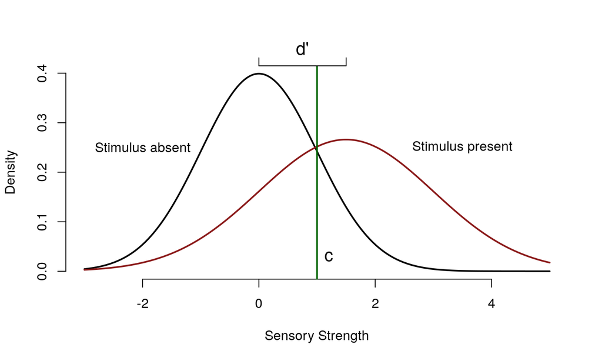

## Unequal Variance Signal Detection Model (UVSD)

Downside:

- This is an extremely flexible mode
- Can fit nearly all data patterns
- Not that many parameters
- Often preferred in frequentist model comparison
- Interpretation difficult

## Unequal Variance Signal Detection Model (UVSD)

```r
## Unequal-Variance Signal Detection Model
ll.sdt.uv <- function(par, y){
  # length(par) == 7 (d1, d2, d3, c, s1, s2, s3)
  ll=0
  for(i in 1:length(N)){ # for each set size
    p = sdt(d = par[i], c = par[length(N) + 1], s = par[length(N) + 1 + i])
    ll = ll + negLL(y[N_i==i], p)
  }
  if(any(par[5:7] < rep(0,3))){
    ll = ll + 10000} # penalty for going out of range
  return(ll)
}
```

## Unequal Variance Signal Detection Model (UVSD)

```r
## fit uvsd model
par = runif(n = 7, min = .1, max = 3)
sdt_res_uv = optim(par, ll.sdt.uv, y = group_data)
sdt_res_uv$par
```

```
## [1] 1.3443677 2.9204704 0.9506075 0.6888061 0.3612327 2.0704380 0.3594712
```

```r
## fit evsd model
par = runif(n = 4, min = .1, max = 3)
sdt_res = optim(par, ll.sdt.ev, y = group_data)
sdt_res$par
```

```
## [1] 2.5037678 1.7666796 1.4167898 0.6887779
```

```r
c(sdt_res_uv$value, sdt_res$value)
```

```
## [1] 1912.392 1912.392
```

## Akaike information criterion (AIC)

\[AIC = - 2 \log(L) + 2 p,\]

## Bayesian information criterion (BIC)

\[AIC = - 2 \log(L) + 2 p,\]

where \(p\) is the number of parameters and \(- 2 \log(L)\) is two times the negative log likelihood.

\[BIC = - 2 \log(L) + p \log(n),\]

where \(n\) is the number of observations.

*Q:* Do you want higher or lower values of AIC/BIC?

## AIC and BIC in R

```r
# function to calculate fit statistics from -LL
fit_stats <- function(nLL, n, p){
  # nLL = negative log liklihood
  # n = number of observations
  # p = number of parameters

  deviance = 2*nLL
  aic = deviance + 2*p
  bic = deviance + p*log(n)

  return(list("D" = deviance, "AIC" = aic, "BIC" = bic))
}
```

## AIC and BIC in R

```r
sdt_fit = fit_stats(nLL = sdt_res$value, n = sum(group_data), p = 4)
k_fit = fit_stats(nLL = k_res$value, n = sum(group_data), p = 3)
vary_k_fit = fit_stats(nLL = vary_k_res$value, n = sum(group_data), p = 5)

c(sdt_fit$AIC, k_fit$AIC, vary_k_fit$AIC)
```

```
## [1] 3832.784 3608.646 3612.189
```

```r
c(sdt_fit$BIC, k_fit$BIC, vary_k_fit$BIC)
```

```
## [1] 3858.096 3627.631 3643.830
```

## AIC and BIC in R

```r
sdt_fit = fit_stats(nLL = sdt_res$value, n = sum(group_data), p = 4)
k_fit = fit_stats(nLL = k_res$value, n = sum(group_data), p = 3)
vary_k_fit = fit_stats(nLL = vary_k_res$value, n = sum(group_data), p = 5)

c(sdt_fit$AIC, k_fit$AIC, vary_k_fit$AIC)
```

```
## [1] 3832.784 3608.646 3612.189
```

```r
c(sdt_fit$BIC, k_fit$BIC, vary_k_fit$BIC)
```

```
## [1] 3858.096 3627.631 3643.830
```

Remember: The lower the better

## AIC and BIC

- Can also be used to compare model fit for all individuals independently
- A landscape of information criterial
- s (participants) x m (models) AIC or BIC
- Who is fit best by model m?
- Which model fits participant s' data best?
- Go to `mle-rouder08-indiv.R`

## Problems & Fixes: Null counts

## Null counts

- Occasional absence of either miss or false-alarm event
- Especially problematic for SDT
- Especially problematic when fitting models to individuals' data

## Null counts

There is an easy fix:

\[ \hat{p}_h = \frac{y_h + .5}{N_s + 1}, \\ \hat{p}_f = \frac{y_f + .5}{N_f + 1}. \]

This is done by adding \(+.5\) to each observed cell count

## Null counts

This is done by adding \(+.5\) to each observed cell count

```r
# this loop takes the data from each row (participant) and fits the three models
for (s in 1:S){
  # get the data for this subject
  tmp.dat = as.integer(cd[s,]) + .5

  # model that freely estimates response frequencies
  fit_statistics[s,1] <- ll.vacuous(y = tmp.dat)

  ...
```

You can find the code at the end of `mle-rouder08-indiv.R`